# Time Series: A First Course with Bootstrap Starter

# Lesson 12-3: The Plug-in Principle and the Bootstrap

- We describe the plug-in method of constructing estimators, which generalizes the method-of-moments.

## Definition 12.3.1.

- If $X_1, \ldots, X_n$ are i.i.d. with common cdf $G$, then their empirical distribution function (edf) is
  $$\widehat{G} (x) = \frac{1}{n} \sum_{i=1}^n 1_{ \{ X_i \leq x \} }.$$

## Paradigm 12.3.5. The Plug-In Principle

- The edf converges uniformly to the cdf, so we can estimate $\theta$ by *plugging in*:
  $$\widehat{\theta} = \theta ( \widehat{G}).$$
- This is called a *plug-in estimator*.
- It generalizes method-of-moments.

## Example 12.3.8. Plug-In Estimator of the Median

The plug-in estimator for the median is
$$\widehat{\theta} = \widehat{G}^{-1} (1/2),$$
which is the sample median.

## Paradigm 12.3.9. Classical Bootstrap for the Variance of a Statistic

- Consider a scenario where we want to know the variance of a statistic $\widehat{\theta}_n$ (computed from a sample of size $n$).
- Let $\eta = \mbox{Var} [ \widehat{\theta}_n]$. Since $n$ is fixed and the sample is i.i.d., $\eta = \eta (G)$.
- We could estimate $\eta$ with the plug-in estimator.
- We would like to compute $\eta (\widehat{G})$, but maybe there is no formula!
- So we try to approximate it using the *bootstrap*.
1. For large $M$ simulate
   $$\begin{align*}
   & X_1^{*(1)}, \ldots, X_n^{*(1)} \sim \mbox{i.i.d.} \widehat{G} \\
   & X_1^{*(2)}, \ldots, X_n^{*(2)} \sim \mbox{i.i.d.} \widehat{G} \\
   \vdots & \\
   & X_1^{*(M)}, \ldots, X_n^{*(M)} \sim \mbox{i.i.d.} \widehat{G}.
   \end{align*}$$
2. For $1 \leq j \leq M$ compute $\widehat{\theta}_n^{*(j)}$ from the *pseudo-sample* $X_1^{*(j)}, \ldots, X_n^{*(j)}$.
3. Our bootstrap estimator of $\eta$ is
   $$\frac{1}{M} \sum_{j=1}^M {\left( \widehat{\theta}_n^{*(j)}
   - M^{-1} \sum_{k=1}^M \widehat{\theta}_n^{*(k)} \right)}^2.$$

## Example 12.3.10. Bootstrap for the Variance of U.S. Population Acceleration

- Consider the time series $\{ Y_t \}$ of U.S. Population.
- One possible model is twice differencing, for which the series appears to be white noise.

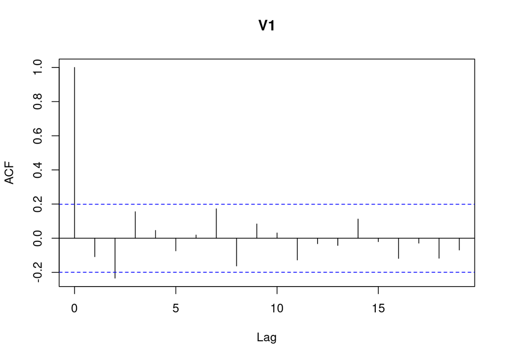

```r
pop <- read.table("USpop.dat")
pop <- ts(pop, start = 1901)
pop.diff <- diff(diff(pop))*10^(-3)
acf(pop.diff)
```

- Suppose that $X_t = {(1-B)}^2 Y_t$ is actually i.i.d.
- The sample mean of $\{ X_t \}$ is 9.8227835 in units of millions.
- Suppose we want to estimate the variance of this sample mean using the bootstrap (of course we could use a formula as well) with $M = 10^5$.

```r
n <- length(pop.diff)
pop.mean <- mean(pop.diff)
pop.edf <- sort(pop.diff)

monte.means <- NULL
Monte <- 100000
for(i in 1:Monte)
{
    monte.sample <- sample(pop.edf,size=n,replace=TRUE)
    monte.means <- c(monte.means,mean(monte.sample))
}
var.mean <- var(monte.means)
```

- The resulting estimate is 636.1785289 in units of millions.
- Note: results change each time notebook is rendered, because seed is not fixed!